# 2_2_population pyramids

# Building a Population Pyramid

Now that we have a handle on the basic plotting features of `ggplot`, and we have talked about distributions and visualized them as histograms, I think we are ready to try and tackle the creation of a population pyramid chart. Recall for a moment on what a population pyramid looks like. We can describe it in terms of what we’ve been talking about this week – it’s just two histograms turned on their side so that they share an x axis, which becomes the y axis, with one group featured on the left and another on the right. In the case of most population pyramids, this data is split by gender, and the x axis is the number of people while the y axis is the age of people.

[figure not shown]

Population Pyramid from Course 1

We know how to do most of these things – how to calculate frequencies, build histograms, render different plots and layers together, and so forth. But we haven’t talked about flipping things on their side, so that sounds fun to explore, and at the same time let’s dive into some of the primitives for drawing in `ggplot`. And just for fun, I’m going to make one little tweak to the population pyramid, and render each side as a **stacked histogram**, so that we can see one more variable.

### Cleaning the BRFSS Data

I’m going to use the BRFSS data since we’ve spent a decent amount of time with it and can get going on it quickly. I’m going to add in one new variable (ADDEPEV3) which is the answer to the question **Have you ever been told or have had a depressive disorder (including depression, major depression, dysthymia, or minor depression)?** I think mental health is a critical issue facing us in society, and I’d be interested to see how this breaks down over age and sex populations in the american population.

```r
# Let's bring in our data cleaning from the previous lecture
library("tidyverse")
library("janitor")
library("foreign")
library("tidylog")
# Here are some human readable labels from the codebook
income2_levels=c("< $10,000", "< $15,000", "< 20,000", "< 25,000", "< 35,000", "< 50,000", "< 75,000", ">= $75,000")
x_race_levels=c("White", "Black", "Amer. Ind. Alaskan Nat.", "Asian", "Native Haw. or Pac. Isl.", "Other", "Multiracial", "Hispanic")
x_sex_levels=c("Male","Female")
x_ageg5yr_levels=c("18-24","25-29","30-34","35-39","40-44","45-49","50-54","55-59","60-64","65-69","70-74","75-79","80+")
addepev3_levels=c("Yes","No")

data <- read.xport("LLCP2020.XPT", fill = NA) |>
  # Clean data formats
  clean_names() |>
  # Choose variables (columns) we want
  select(x_race,income2,wtkg3,htm4,x_sex,x_ageg5yr,addepev3) |>
  # Filter for observations (rows) of interest
  filter(between(x_race,1,8)) |>
  filter(between(income2,1,8)) |>
  filter(between(wtkg3,2300,29500)) |>
  filter(between(htm4,91,244)) |>
  filter(between(x_sex,1,2)) |>
  filter(between(x_ageg5yr,1,13)) |>
  filter(between(addepev3,1,2)) |>
  # Convert datatypes (factors and labels on levels)
  mutate(
    x_sex=lvls_revalue(as_factor(x_sex), x_sex_levels),
    x_race=lvls_revalue(as_factor(x_race), x_race_levels),
    x_ageg5yr=lvls_revalue(as_factor(x_ageg5yr), x_ageg5yr_levels),
    income2=lvls_revalue(as_factor(income2), income2_levels),
    addepev3=lvls_revalue(as_factor(addepev3), addepev3_levels))
```

```
## select: dropped 272 variables (x_state, fmonth, idate, imonth, iday, …)
## filter: removed 8,988 rows (2%), 392,970 rows remaining
## filter: removed 75,810 rows (19%), 317,160 rows remaining
## filter: removed 14,032 rows (4%), 303,128 rows remaining
## filter: removed 2,764 rows (1%), 300,364 rows remaining
## filter: no rows removed
## filter: removed 1,845 rows (1%), 298,519 rows remaining
## filter: removed 1,007 rows (<1%), 297,512 rows remaining
## mutate: converted 'x_race' from double to factor (0 new NA)
##         converted 'income2' from double to factor (0 new NA)
##         converted 'x_sex' from double to factor (0 new NA)
##         converted 'x_ageg5yr' from double to factor (0 new NA)
##         converted 'addepev3' from double to factor (0 new NA)
```

```r
data |> head()
```

```
##   x_race   income2 wtkg3 htm4  x_sex x_ageg5yr addepev3
## 1  White < $10,000  4808  170 Female     55-59      Yes
## 2  White  < 35,000  8165  175   Male     65-69       No
## 3  White  < 50,000  6804  168 Female     75-79       No
## 4  Black  < 35,000  6804  160 Female     65-69      Yes
## 5  White  < 50,000  7711  180 Female     40-44       No
## 6  White  < 75,000  6078  168 Female     70-74       No
```

Isn’t that beautiful? So succinct and readable, and code that’s really easy to maintain and change as our analyses might. I of course wanted to throw one more thing at you, and introduced the `lvls_revalue` function which is actually from the `forcats` package. It allows us to take a character vector the same length as our levels and just overwrite the level names. We did this previously with the `levels` function, but that function is not easy to pass into the `tidyverse` pipe-based cleaning, so to use it here would have required additional statements.

## Calculating Frequencies

```r
grouped_data <- data |>
  # We can group by all unique combinations of our variables by listing them here
  group_by(x_ageg5yr, x_sex, addepev3) |>
  # And we'll create a new column called population to hold our frequencies
  summarise(population = n())
```

```
## group_by: 3 grouping variables (x_ageg5yr, x_sex, addepev3)
## summarise: now 52 rows and 4 columns, 2 group variables remaining (x_ageg5yr, x_sex)
```

Now for a little trick – we want the population centered around zero, and we’ll eventually flip this from an x axis into a y axis. So we want half of our sample, by sex, to be negative values, and we want the other half of the sample to be positive values. That will give us the unique ribbing effect of the population plot. Since we’ve converted things into factors already it gets a little bit harder to do this. I could go back and undo the factor conversion, but I want you to see how we can compare values which are factors to the level labels.

```r
# If we wanted to negate all values where x_sex=="Female" that would be a
# straight forward mutate call. But we don't have strings anymore, we have a
# factor and it has two levels. This means we want to extract a single level
# object -- one label in our factor -- for comparison. Since we created our
# levels as ("Male","Female"), the level we want to extract is in the second
# position of this vector, so we can pull out our base R query syntax
women <- levels(grouped_data$x_sex)[2]

# Now a quick mutate to change the population values for women to be negative
grouped_data <- grouped_data |>
  mutate(population = ifelse(x_sex==women, -population, population))
```

```
## mutate (grouped): changed 26 values (50%) of 'population' (0 new NAs)
```

```r
# And lets look at our grouped tibble
head(grouped_data)
```

```
## # A tibble: 6 × 4
## # Groups:   x_ageg5yr, x_sex [3]
##   x_ageg5yr x_sex  addepev3 population
##   <fct>     <fct>  <fct>         <int>
## 1 18-24     Male   Yes            1489
## 2 18-24     Male   No             7805
## 3 18-24     Female Yes           -2466
## 4 18-24     Female No            -5393
## 5 25-29     Male   Yes            1343
## 6 25-29     Male   No             7052
```

## Building our histograms

Now that we have our base data we just need to visualize it! I’m going to start by building base histograms, and since we have the frequency data calculated this is going to be a `geom_bar` layer. Now, I want to color the bars based on four factors, Yes to the mental health question and Male, No to the mental health question and Male, Yes to the mental health question and Female, and No to the mental health question and Female. We could have done this in `dplyr` with a new column and reduced our `tibble`, but I want to show you how you can do this on the fly in `ggplot`. I’m going to use a function called `interaction`, which simply takes a list of factors (in this case `addepev3` and `x_sex`) and creates a new factor which is a multiplication of these. The term interaction is from statistics, and means we are looking for an interaction effect, while another way to refer to this is a Cartesian product or if you use SQL a cross join.

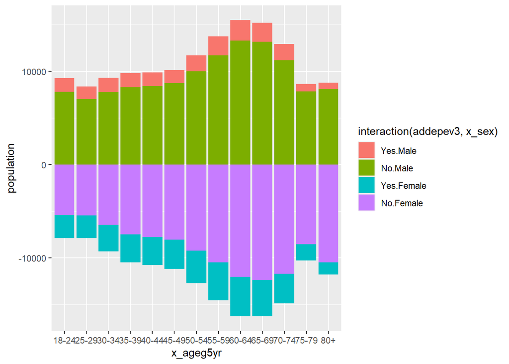

```r
# I'll pass in the aesthetics to our base plot, and I'll set the fill of the
# bars to be this new interaction factor, while the height will be our population
# frequency value and our x the ages. By default a geom_bar uses the stat value
# of count, but here we already have our values in our dataframe, so I'm going
# to override that and set the stat to identity, which tell geom_bar to do no
# statistical transform
gg_pop <- ggplot(grouped_data, aes(x = x_ageg5yr ,
                           fill = interaction(addepev3,x_sex),
                           y = population)) +
  geom_bar(stat = "identity")
print(gg_pop)
```

Ok, so what we have now is a stacked histogram, where the Female population is on the bottom, the Male population is on the top, and we have our interaction effect variable in color. If you tilt your head to the right you’ll see this is our population pyramid! Let’s clean that up a bit and make it more presentable. Our first task is to turn it on its side. To do this we are going to modify the coordinates of the plot. Generally we use Cartesian coordinates for most plots, however there are other kinds of coordinate systems we can use. In this case we just want to flip the x and y, and `ggplot` has a function called `coord_flip` to do this. Keep in mind that the coordinates affect all layers, though right now we just have one layer on top of our base.

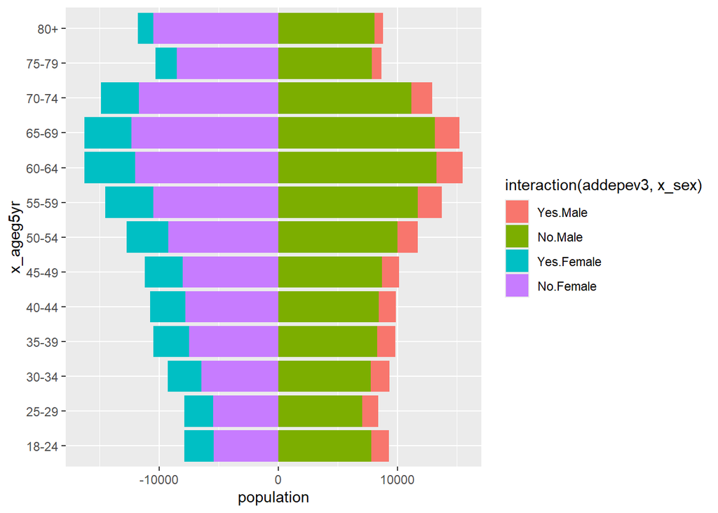

```r
# I'll just add in that coordinate flipping to our plot
gg_pop <- gg_pop +
  coord_flip()
print(gg_pop)
```

That’s all there is to it, a nice looking population pyramid!

## Improving the Visuals

Ok, nice looking might be a bit too far. It’s functional, but I’m not sure I would put this in front of a decision maker yet. First, all of our labels are pretty basic or missing, the x axis labels are wrong from women, and the colors are pretty garish, and it’s not very intuitive. So let me show you how I might fix this up. First up, some real labels.

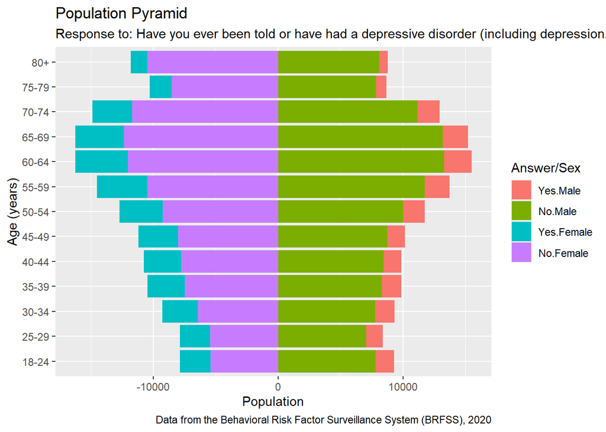

```r
gg_pop <- gg_pop +
    labs(title="Population Pyramid",
         subtitle="Response to: Have you ever been told or have had a depressive disorder (including depression, major depression, dysthymia, or minor depression)?",
         caption="Data from the Behavioral Risk Factor Surveillance System (BRFSS), 2020",
         y="Population",
         x="Age (years)",
         fill="Answer/Sex")
print(gg_pop)
```

We’ll come back to the legend in a bit, but let’s fix up the units on that new `x` axis. We still refer to this as the `y` axis, because it is, our plot is just being flipped, so watch out for that. When we want to change tick marks we’re going to use the `scale_` functions. In this case I’m going to use the scale function and change the labels by using the absolute value of the labels. I also want to see more values along that axis, so I’m going to give a nudge to `ggplot` to try and render more tick label vales.

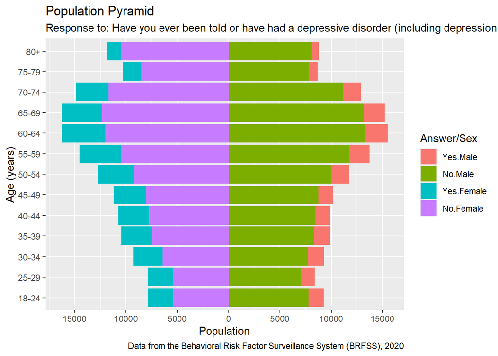

```r
# The labels assignment in this case is just taking in a function, which means
# that it's going to apply that function to all of the labels. To nudge ggplot
# to improve the scale I'm going to set the number of major breaks to 10. This
# is just a hint to ggplot, it's still going to make something beautiful and
# balanced, so if you want to insist on certain breaks you can pass a vector
# in as the breaks argument instead
gg_pop <- gg_pop +
  scale_y_continuous(labels = abs, n.breaks=10)
print(gg_pop)
```

I’m not a big fan of these colors. They are certainly distinct, but we can tweak them to make them fit in with, say, other charts or literature we might be presenting to stakeholders. In this case I’m going to use the University of Michigan colors. Now, when I came to Michigan ten years ago I have to tell you, I was a little taken aback – everyone in the town is wearing navy blue and yellow, and not a subtle faded yellow but a screaming bright yellow. What I was quick to be told though is that it’s not yellow, but **maize**, which is another word for corn. So I’m going to use the official Michigan colors of maize and blue, and I just looked up the color identification codes on the website. There are lots of color pickers which will allow you to find the appropriate hex codes for colors you might be interested in.

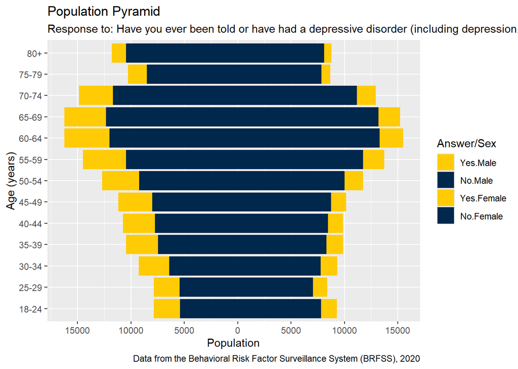

```r
# Here's our colors
maize_and_blue<-c("#FFCB05","#00274C","#FFCB05","#00274C")

# Now remember, we change visual aspects of aesthetics by scaling them, so in
# this case we want to scale the fill color. This might seem pretty unintuitive
# when you first do it.

# Also, we have four values, but I only want two colors, where the Yes values
# are maize and the No values are blue. So I've designed my vector of colors
# with four items in it
gg_pop <- gg_pop +
  scale_fill_manual(values=maize_and_blue)
print(gg_pop)
```

I will say that, after being in Michigan for ten years, half my wardrobe is now maize and blue and it seems perfectly normal to me! Now, I think we could increase the clarity in the main plot by tweaking a few things. Once the high level details of the data rendering are done we can change visual aspects of a chart with `ggplot` themes. I’ll be honest, I use the themes which come with `ggplot` to create fairly minimal graphics for academic publishing. But there is a fair bit of customization available and in the last week of this course we will talk about some of the things you might want to consider when customizing your plots. And, as you can imagine, the `theme()` function affects all layers in the plot.

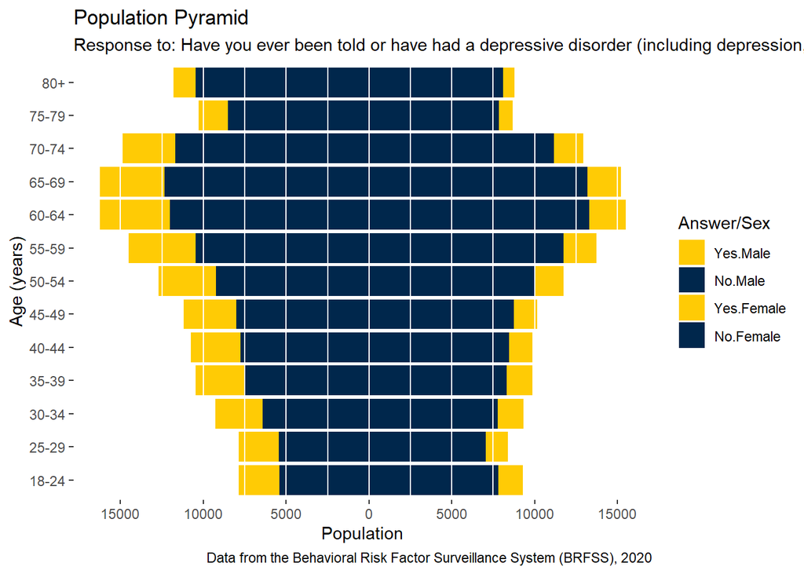

```r
# The theme() function just maps a number of different features of the plot and
# you can look at the docs for more details. In this case I'm going to wipe
# out the background color and fill by setting that to NA, then I'm going to
# set the grid lines to white and remove the grid lines for the y axis, and
# finally I'll put the background panel *on top* of the plot so it breaks up
# out bars.
pop_theme <- theme(
  panel.background = element_rect(fill = NA, colour = NA),
  panel.grid.major = element_line(size = 0.5, linetype = 'solid',
                                color = "white"),
  panel.grid.minor = element_line(size = 0.5, linetype = 'solid',
                                color = "white"),
  panel.ontop = TRUE,
  panel.grid.major.y = element_blank(),
  panel.grid.minor.y = element_blank()
  )
gg_pop <- gg_pop + pop_theme
print(gg_pop)
```

Now that we’ve gotten to this point I’m not loving that the tick mark at 0 is the same as the rest and this makes it a bit difficult to see where the women and men are divided. With the panel rendered on top though, the only way to fix this is to remove it, and render a new line.

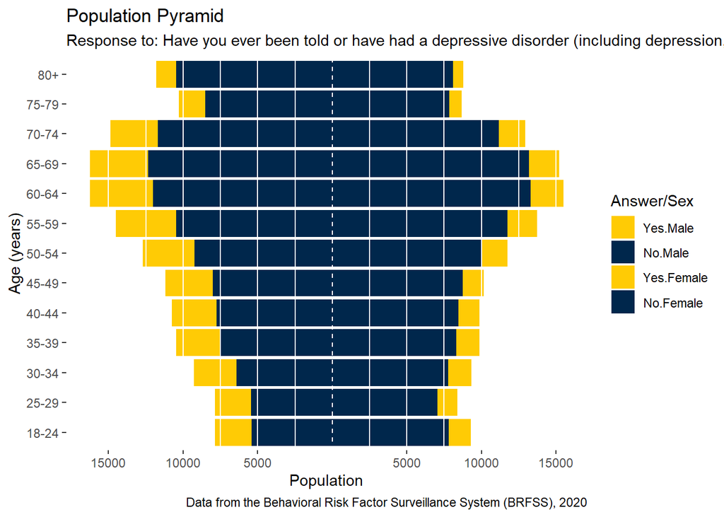

```r
# First I'm going to hard code in the major and minor axis breaks, removing the
# one which would show up at 0. Then I'm going to draw a new horizontal line
# using geom_hline at the y coordinate of 0. Why a horizontal line? Because we
# flip our chart, so it will actually show up as a vertical line :)
gg_pop <- gg_pop + scale_y_continuous(labels = abs,
                                      breaks=c(15000,10000,5000,-5000,-10000,-15000),
                                      minor_breaks=c(12500,7500,2500,-2500,-7500,-12500)) +
  geom_hline(yintercept = 0,linetype='dashed', col = 'white')
print(gg_pop)
```

Ok! Now let’s directly render in the Male and Female labels so we can reduce the legend to just yes and no.

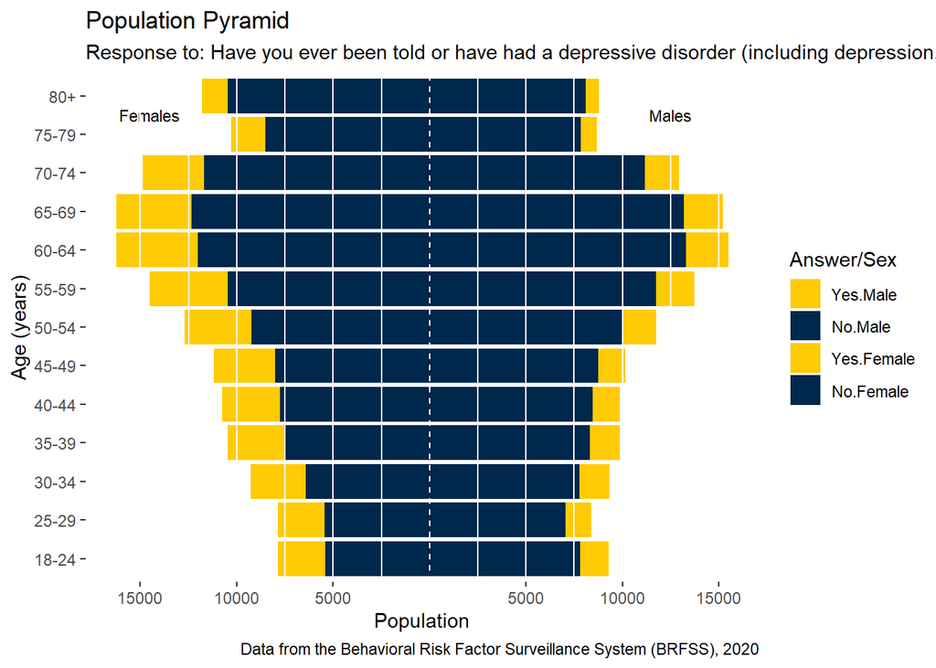

```r
# Annotations are tricky here! Remember our axes values, one of them is a
# factor and the other is continuous. So if we want the females and males
# text to show up towards the top of the plot, we're actually going to use the
# x position -- which is now our visual y axis - as the number of factors high
# that we want the label rendered!
gg_pop <- gg_pop +
  annotate("text",
           y = c(-14500,12500),
           x = c(12.5,12.5),
           label = c("Females", "Males"),
           color="black",
           size=3)
print(gg_pop)
```

*sigh*

The struggle is real when it comes to producing a really unique visual. In this case our rendered panel is on top of our data, which is great but now it also runs through our labels making them look a little wonky with white lines overlapping. I wanted to show you my real struggle to try and put this together – it’s not like I just sat down and rattled off the final version! Experimentation and persistence was required as new design issues came up. A fix for this is to put our panel back below the data plot and manually plot some more horizontal (which will be flipped to vertical) lines.

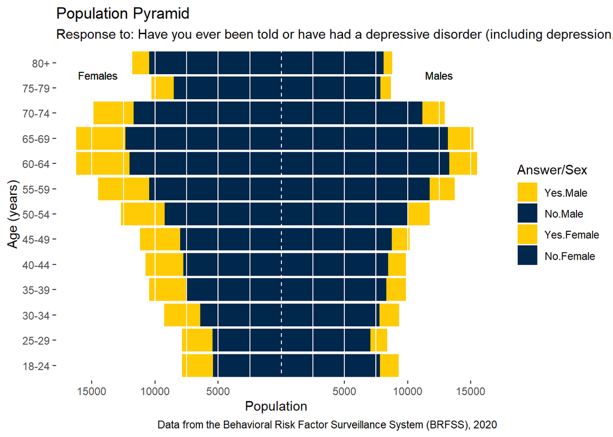

```r
# Wipe out most of the theme -- your plot can only have one theme at a time
pop_theme <- theme(
  panel.background = element_rect(fill = NA, colour = NA),
  panel.ontop = FALSE,
  panel.grid.major.y = element_blank(),
  panel.grid.minor.y = element_blank()
  )
gg_pop <- gg_pop + pop_theme

# Now plot a bunch of full height white ticklines
for (z in c(15000,12500,10000,7500,5000,2500,-2500,-5000,-7500,-10000,-12500,-15000)){
  gg_pop <- gg_pop + geom_hline(yintercept = z,linetype='solid', col = 'white')
}

# Now put our annotations on top. Technically I have the old ones in the plot
# still, I would go back and fix this with my final version once I've massaged
# things as I would like
gg_pop <- gg_pop +
  annotate("text",
           y = c(-14500,12500),
           x = c(12.5,12.5),
           label = c("Females", "Males"),
           color="black",
           size=3)
print(gg_pop)
```

Now I’m going to plot the legend manually inside the graphic. So I need to tell `ggplot` to just drop the legend and then I’ll make a few objects myself.

```r
print( gg_pop + theme(legend.position = "none") +
  annotate("text", x = c(4.5,3.5), y = c(15500,15500),
              label = c("Yes","No"),
              size=4) +
  annotate("rect",
           xmin = c(4,3),
           xmax = c(5,4),
           ymin = c(12300,12300),
           ymax = c(14300,14300),
           alpha= 1,
           fill= maize_and_blue[1:2])
)
```

[figure not shown]

Ooooh it’s looking good! Last thing I’m going to do is fix up that title. We need to manually add in returns for the title as `ggplot` does not wrap. I’ll do this and show you the whole code in this last chunk.

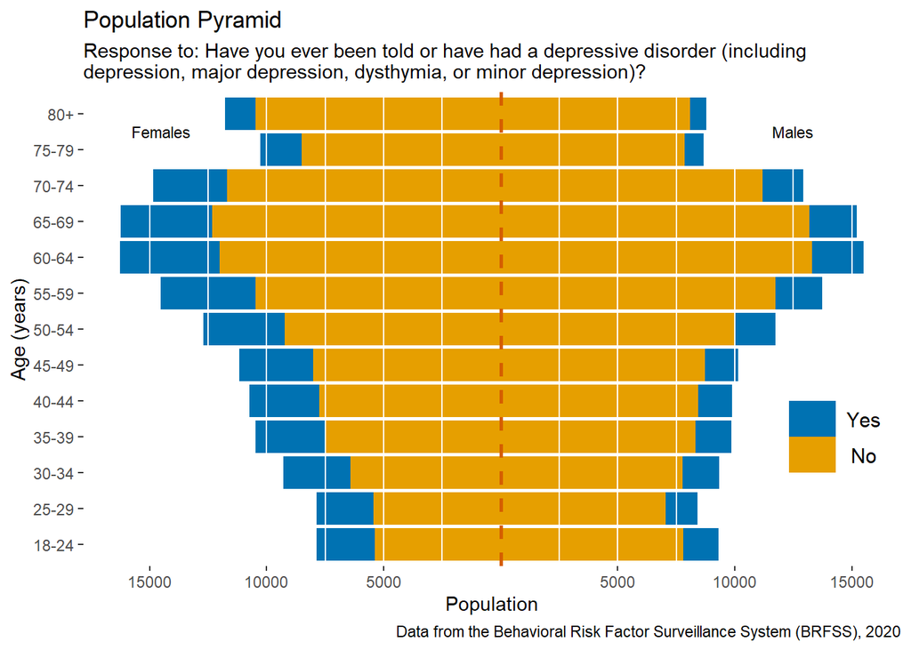

```r
# Our plot colors have changed, making them more colorblind friendly, along with dashed hline in the middle at 0 population.
blue_and_orange<-c("#0072B2","#E69F00","#0072B2","#E69F00")

# Our tick line coordinates
ticklines <- c(15000,12500,10000,7500,5000,2500,-2500,-5000,-7500,-10000,-12500,-15000)

plt <- ggplot(grouped_data, aes(x = x_ageg5yr ,
                                fill = interaction(addepev3,x_sex),
                                y = population)) +
  geom_bar(stat = "identity")

# Add in our ticklines
for (z in ticklines){
  plt <- plt + geom_hline(yintercept = z,linetype='solid', col = 'white')
}

# Create the rest of the plot
plt <- plt +
  labs(title="Population Pyramid",
         subtitle="Response to: Have you ever been told or have had a depressive disorder (including\ndepression, major depression, dysthymia, or minor depression)?",
         caption="Data from the Behavioral Risk Factor Surveillance System (BRFSS), 2020",
         y="Population",
         x="Age (years)",
         fill="Answer/Sex") +
  scale_fill_manual(values=blue_and_orange) +
  scale_y_continuous(labels = abs,
                     breaks=c(15000,10000,5000,-5000,-10000,-15000),
                     minor_breaks=c(12500,7500,2500,-2500,-7500,-12500)) +
  # The white line has been replaced by a dashed hline at 0 population seperating the 'males' and 'females'
  geom_hline(yintercept = 0, linetype='dashed', linewidth=1.05 , col = '#D55E00') +
  #geom_text(aes(label = count(addepev3)) +
  coord_flip() +
  annotate("text", x = c(4.5,3.5), y = c(15500,15500),
              label = c("Yes","No"),
              size=4) +
  annotate("rect",
           xmin = c(4,3),
           xmax = c(5,4),
           ymin = c(12300,12300),
           ymax = c(14300,14300),
           alpha= 1,
           fill= blue_and_orange[1:2]) +
  annotate("text",
           y = c(-14500,12500),
           x = c(12.5,12.5),
           label = c("Females", "Males"),
           color="black",
           size=3) +
  theme(
    legend.position = "none",
    panel.background = element_rect(fill = NA, colour = NA),
    panel.grid.major.y = element_blank(),
    panel.grid.minor.y = element_blank()
  )

# Show the image
print(plt)
```

```r
# And save it to a file
ggsave("output2.png", plt, width=7, height=7, units="in")
```

Ok, look at that masterpiece!

## Wrapup

Now, I’m not the worlds best designer, but I think being able to show this kind of custom plot, a population pyramid, from the raw data is a pretty remarkable feat for us in just a course and a half. This plot quickly shows that this sample has more older women in it, and that women answer yes to the question of depression more frequently than men do throughout the range of data.

Importantly, you’ve seen a very authentic workflow – how I took this data and explored it, converting it to a graphic which might be useful for a stakeholder, and then theming it to match with a context I might present it in. I added more visual embellishments than I normally would, and this is something we’ll discuss a bit in the last week of this course, but I wanted to introduce you to themes in R. At the end of the day, the kind of visual you produce will depend on who you are trying to communicate with – a statistician, a decision maker, or the general public.